# Integración multi-ómica de la firma de interferón y biomarcadores séricos en LES

Análisis MOFA2 (Multi-Omics Factor Analysis) — Integración no supervisada

Fuensanta Bernal Gómez

09 de May de 2026

```r
ruta_fig <- knitr::opts_chunk$get("fig.path")
dir.create(ruta_fig, showWarnings = FALSE, recursive = TRUE)
```

# 1 Introducción

En este documento se presenta un análisis de **integración multi-ómica no supervisada** en pacientes con lupus eritematoso sistémico (LES) mediante el método **MOFA2** (*Multi-Omics Factor Analysis v2*) [@Argelaguet2020]. MOFA2 es un marco bayesiano de factorización matricial conjunta que descompone la variación de múltiples capas ómicas en un conjunto reducido de **factores latentes** compartidos o específicos de cada bloque, sin necesidad de definir una variable respuesta *a priori*.

A diferencia de DIABLO, que opera de forma supervisada, MOFA2 permite descubrir la **estructura latente intrínseca** de los datos, identificando fuentes de variación coordinadas entre bloques que permanecerían ocultas en análisis unicapa. Los factores obtenidos pueden posteriormente correlacionarse con las variables clínicas de actividad y remisión (SLEDAI-2K, SLE-DAS, LLDAS, DORIS), proporcionando una interpretación biológica y clínica directa.

Se integran dos bloques ómicos medidos en la misma muestra de pacientes:

- **Bloque transcriptómico:** expresión de 72 genes estimulados por interferón (ISGs) cuantificados mediante NanoString nCounter, normalizados y transformados a escala log2.
- **Bloque proteómico sérico:** panel de citocinas (IFN-α, IFN-γ, IL-2, IL-6, IL-8, BAFF), factores del complemento (C3, C4), marcadores de inflamación (PCR), función renal (creatinina), perfil lipídico (colesterol, triglicéridos, HDL, LDL, Apo A-I, Apo B, cociente Apo B/A-I, lipoproteína(a)) y parámetros hepático-nutricionales (GOT, GPT, GGT, proteínas totales).

# 2 Carga de paquetes

```r
if (!requireNamespace("BiocManager", quietly = TRUE))
  install.packages("BiocManager")

if (!requireNamespace("MOFA2", quietly = TRUE))
  BiocManager::install("MOFA2")

if (!requireNamespace("basilisk", quietly = TRUE))
  BiocManager::install("basilisk")

paquetes_cran <- c(
  "dplyr", "tidyr", "ggplot2", "knitr", "kableExtra",
  "tibble", "forcats", "scales", "purrr", "broom", "ggpubr",
  "RColorBrewer", "reshape2", "VIM", "pheatmap", "corrplot"
)

for (pkg in paquetes_cran) {
  if (!requireNamespace(pkg, quietly = TRUE)) install.packages(pkg)
  library(pkg, character.only = TRUE)
}

library(MOFA2)

select <- dplyr::select
filter <- dplyr::filter
```

# 3 Paleta de colores

```r
# Paleta IFN-high / IFN-low
col_ifn_high <- "#d73027"   # rojo — IFN-high
col_ifn_low  <- "#4575b4"   # azul — IFN-low

col_ifn <- c("IFN-high" = col_ifn_high, "IFN-low" = col_ifn_low)

# Paletas para variables clínicas continuas
pal_sledai <- "YlOrRd"
pal_factor <- "RdBu"
```

# 4 Bloque 1. Preparación de datos

## 4.1 Importación del dataset

```r
df <- readRDS("DataSet_CorrelacionBivariada.rds")
df <- as.data.frame(df)

cat("Dimensiones:", nrow(df), "filas x", ncol(df), "columnas\n")
```

```
## Dimensiones: 251 filas x 120 columnas
```

```r
head(names(df), 10)
```

```
##  [1] "id2"      "varon1"   "les"      "edad"     "duracion" "edadiag"
##  [7] "sledai"   "slicc"    "sledas"   "lldas"
```

## 4.2 Selección de la muestra analítica

```r
# Excluir controles sanos (sin clasificación IFN) — solo pacientes LES entran en MOFA2
df <- df %>%
  filter(!is.na(ifn_grupo)) %>%
  mutate(
    ifn_grupo = factor(
      case_when(
        ifn_grupo %in% c("IFN-high", "high", "1", 1) ~ "IFN-high",
        ifn_grupo %in% c("IFN-low",  "low",  "0", 0) ~ "IFN-low",
        TRUE ~ NA_character_
      ),
      levels = c("IFN-high", "IFN-low")
    )
  ) %>%
  filter(!is.na(ifn_grupo))

cat("Pacientes LES incluidos en MOFA2:\n")
```

```
## Pacientes LES incluidos en MOFA2:
```

```r
cat("→ Total:", nrow(df), "\n")
```

```
## → Total: 251
```

```r
cat("→ IFN-high:", sum(df$ifn_grupo == "IFN-high"), "\n")
```

```
## → IFN-high: 87
```

```r
cat("→ IFN-low: ", sum(df$ifn_grupo == "IFN-low"),  "\n")
```

```
## → IFN-low:  164
```

## 4.3 Definición de los bloques ómicos

### 4.3.1 Bloque transcriptómico (ISGs)

```r
isg_genes <- c(
  "BDCA1","BST2","CEACAM1","CMPK2","CXCL10","CXCL9","DDX60","DNAJA1",
  "EIFAK2","EPSTI1","GBP1","GBP4","GBP5","HERC5","HERC6","IFI16","IFI27",
  "IFI35","IFI44","IFI44L","IFI6","IFIH1","IFIT1","IFIT2","IFIT3","IFIT5",
  "IFITM1","IFITM3","IL1RN","IL6","IRF1","IRF7","ISG15","ISG20","LAMP3",
  "LGALS3BP","LY6E","MX1","MX2","MYD88","NC0A7","NT5C3B","OAS1","OAS2",
  "OAS3","OASL","PARP12","PARP9","PHF11","PLSCR1","PRKR","PSMB9","RSAD2",
  "RTP4","SAMD9L","SERPING1","SIGLEC1","SOCS1","SP100","SP140","SPATS2L",
  "STAT1","TAP1","TNFAIP6","TNFSF10","TRIM38","TYK2","UB2L6","UNC93B1",
  "USP18","XAF1","ZBP1"
)

isg_disponibles <- intersect(isg_genes, names(df))
cat("Genes ISG disponibles:", length(isg_disponibles), "de", length(isg_genes), "\n")
```

```
## Genes ISG disponibles: 72 de 72
```

### 4.3.2 Bloque proteómico sérico

```r
proteinas_sericas <- c(
  "IFNapgml", "IFNgpgml", "IL2pgml", "IL6pgml", "IL8pgml", "baffpgml",
  "c3", "c4",
  "pcrmgl", "creatinina",
  "colesterol", "trigli", "hdl", "ldl", "apoa1", "apob", "apoba",
  "lipoprotein_a",
  "got", "gpt", "ggt", "prot_tot"
)

proteinas_disponibles <- intersect(proteinas_sericas, names(df))
cat("Proteínas séricas disponibles:", length(proteinas_disponibles), "\n")
```

```
## Proteínas séricas disponibles: 22
```

```r
cat("→", paste(proteinas_disponibles, collapse = ", "), "\n")
```

```
## → IFNapgml, IFNgpgml, IL2pgml, IL6pgml, IL8pgml, baffpgml, c3, c4, pcrmgl, creatinina, colesterol, trigli, hdl, ldl, apoa1, apob, apoba, lipoprotein_a, got, gpt, ggt, prot_tot
```

## 4.4 Datos faltantes e imputación en el bloque proteómico

```r
missing_prot <- df %>%
  select(all_of(proteinas_disponibles)) %>%
  summarise(across(everything(), ~ round(100 * mean(is.na(.)), 1))) %>%
  pivot_longer(everything(), names_to = "Variable", values_to = "Pct_NA") %>%
  arrange(desc(Pct_NA))

kable(missing_prot,
      caption = "Tabla 1. Porcentaje de datos faltantes en el bloque proteómico sérico.",
      col.names = c("Variable", "% Faltantes"),
      align = "lc") %>%
  kable_styling(bootstrap_options = c("striped", "hover", "condensed"),
                full_width = FALSE, font_size = 13) %>%
  footnote(general = "Las variables con >70% de datos faltantes se excluyen del bloque proteómico; el resto se imputan mediante kNN (k = 5).",
           general_title = "Nota")
```

Tabla 1. Porcentaje de datos faltantes en el bloque proteómico sérico.

| Variable | % Faltantes |
| --- | --- |
| ggt | 79.3 |
| prot_tot | 75.3 |
| got | 73.3 |
| gpt | 73.3 |
| baffpgml | 67.7 |
| IL2pgml | 29.1 |
| IL6pgml | 29.1 |
| IL8pgml | 29.1 |
| IFNapgml | 3.2 |
| apoba | 2.4 |
| c3 | 2.0 |
| c4 | 2.0 |
| pcrmgl | 2.0 |
| creatinina | 2.0 |
| colesterol | 2.0 |
| trigli | 2.0 |
| hdl | 2.0 |
| ldl | 2.0 |
| apoa1 | 2.0 |
| apob | 2.0 |
| lipoprotein_a | 2.0 |
| IFNgpgml | 0.8 |

Nota  
Las variables con >70% de datos faltantes se excluyen del bloque proteómico; el resto se imputan mediante kNN (k = 5).

## 4.5 Construcción de matrices de bloques

```r
prot_excluir <- missing_prot %>% filter(Pct_NA > 70) %>% pull(Variable)
prot_incluir <- setdiff(proteinas_disponibles, prot_excluir)

cat("Variables proteómicas excluidas (>70% NA):", length(prot_excluir), "\n")
```

```
## Variables proteómicas excluidas (>70% NA): 4
```

```r
if (length(prot_excluir) > 0) cat(" →", paste(prot_excluir, collapse = ", "), "\n")
```

```
##  → ggt, prot_tot, got, gpt
```

```r
cat("Variables proteómicas incluidas:", length(prot_incluir), "\n")
```

```
## Variables proteómicas incluidas: 18
```

```r
df_mofa <- df %>% filter(!is.na(ifn_grupo))
cat("\nN total con ifn_grupo disponible:", nrow(df_mofa), "\n")
```

```
##
## N total con ifn_grupo disponible: 251
```

```r
stopifnot("id2" %in% names(df_mofa))

# Bloque transcriptómico (muestras en filas → transponer para MOFA2)
bloque_isg <- df_mofa %>%
  select(all_of(isg_disponibles)) %>%
  as.matrix()
rownames(bloque_isg) <- df_mofa$id2

# Bloque proteómico: imputación kNN + transformación log2
bloque_prot_raw <- df_mofa %>%
  select(all_of(prot_incluir)) %>%
  as.matrix()
rownames(bloque_prot_raw) <- df_mofa$id2

if (any(is.na(bloque_prot_raw))) {
  cat("\nImputando valores faltantes en bloque proteómico (kNN, k = 5)...\n")
  ids_originales   <- rownames(bloque_prot_raw)
  bloque_prot_imp  <- VIM::kNN(as.data.frame(bloque_prot_raw), k = 5, imp_var = FALSE)
  bloque_prot_imp  <- as.matrix(bloque_prot_imp)
  rownames(bloque_prot_imp) <- ids_originales
} else {
  bloque_prot_imp <- bloque_prot_raw
}
```

```
##
## Imputando valores faltantes en bloque proteómico (kNN, k = 5)...
```

```r
bloque_prot <- log2(bloque_prot_imp + 1)
rownames(bloque_prot) <- rownames(bloque_prot_imp)

# MOFA2 requiere matrices con genes/proteínas en FILAS y muestras en COLUMNAS
mat_isg  <- t(bloque_isg)
mat_prot <- t(bloque_prot)

cat("Bloque ISG  — dimensiones (variables × muestras):", dim(mat_isg),  "\n")
```

```
## Bloque ISG  — dimensiones (variables × muestras): 72 251
```

```r
cat("Bloque Prot — dimensiones (variables × muestras):", dim(mat_prot), "\n")
```

```
## Bloque Prot — dimensiones (variables × muestras): 18 251
```

```r
# Verificar alineación de muestras
stopifnot(identical(colnames(mat_isg), colnames(mat_prot)))
cat("\n✓ Alineación correcta de muestras en ambos bloques.\n")
```

```
##
## ✓ Alineación correcta de muestras en ambos bloques.
```

# 5 Bloque 2. Creación y configuración del modelo MOFA2

## 5.1 Creación del objeto MOFA

```r
data_mofa <- list(
  "Transcriptomica_ISGs" = mat_isg,
  "Proteomica_serica"    = mat_prot
)

MOFAobject <- create_mofa(data_mofa)

cat("Objeto MOFA2 creado:\n")
```

```
## Objeto MOFA2 creado:
```

```r
print(MOFAobject)
```

```
## Untrained MOFA model with the following characteristics:
##  Number of views: 2
##  Views names: Transcriptomica_ISGs Proteomica_serica
##  Number of features (per view): 72 18
##  Number of groups: 1
##  Groups names: group1
##  Number of samples (per group): 251
##
```

## 5.2 Resumen de datos faltantes por bloque

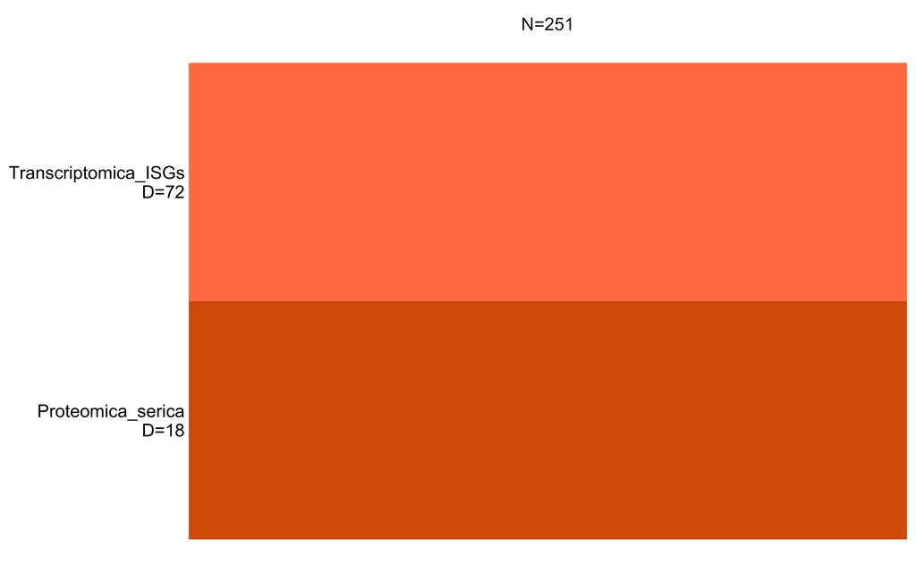

Figura 0. Resumen del objeto MOFA2: distribución de datos disponibles y faltantes por bloque ómico y muestra.

```r
plot_data_overview(MOFAobject)
```

## 5.3 Opciones del modelo y entrenamiento

```r
# ── Opciones del modelo ──────────────────────────────────────────────────────
model_opts <- get_default_model_options(MOFAobject)
model_opts$num_factors       <- 10     # máx. factores; ARD poda los no informativos
model_opts$spikeslab_weights <- TRUE   # sparsity en loadings

# ── Opciones de datos ────────────────────────────────────────────────────────
data_opts <- get_default_data_options(MOFAobject)
data_opts$scale_views <- FALSE         # ya escalamos manualmente

# ── Opciones de entrenamiento ────────────────────────────────────────────────
train_opts <- get_default_training_options(MOFAobject)
train_opts$convergence_mode <- "slow"  # "fast" | "medium" | "slow"
train_opts$seed             <- 42
train_opts$maxiter          <- 1000

MOFAobject <- prepare_mofa(
  object           = MOFAobject,
  data_options     = data_opts,
  model_options    = model_opts,
  training_options = train_opts
)

cat("  Número máximo de factores:", model_opts$num_factors, "\n")
```

```
##   Número máximo de factores: 10
```

```r
cat("  Sparsity en loadings (spike-slab):", model_opts$spikeslab_weights, "\n")
```

```
##   Sparsity en loadings (spike-slab): TRUE
```

```r
cat("  Modo de convergencia:", train_opts$convergence_mode, "\n")
```

```
##   Modo de convergencia: slow
```

```r
cat("  Iteraciones máximas:", train_opts$maxiter, "\n")
```

```
##   Iteraciones máximas: 1000
```

```r
cat("  Semilla aleatoria:", train_opts$seed, "\n")
```

```
##   Semilla aleatoria: 42
```

# 6 Bloque 3. Entrenamiento del modelo MOFA2

```r
outfile <- file.path(getwd(), "MOFA2_LES_model.hdf5")

# Suprimir output de Python
con_out <- file(tempfile(), open = "wt")
con_msg <- file(tempfile(), open = "wt")
sink(con_out, type = "output")
sink(con_msg, type = "message")

MOFAobject_trained <- run_mofa(
  MOFAobject,
  outfile      = outfile,
  use_basilisk = TRUE
)

sink(type = "output")
sink(type = "message")
close(con_out)
close(con_msg)
```

```r
cat("✓ Modelo MOFA2 entrenado y guardado en:\n →", outfile, "\n")
```

```
## ✓ Modelo MOFA2 entrenado y guardado en:
##  → /Users/fuensantagomezbernal/Library/CloudStorage/GoogleDrive-fuensanta95@gmail.com/Mi unidad/TFM/Base de datos/MOFA2_LES_model.hdf5
```

```r
cat("✓ Factores activos tras ARD:", get_dimensions(MOFAobject_trained)$K, "\n")
```

```
## ✓ Factores activos tras ARD: 4
```

## 6.1 Adición de metadatos clínicos

```r
metadata <- df_mofa %>%
  select(id2, sledai_cat, sledas_cat, sledai, sledas, slicc, lldas, doris) %>%
  rename(sample = id2)

samples_metadata(MOFAobject_trained) <- metadata

kable(head(samples_metadata(MOFAobject_trained), 6),
      caption = "Tabla 2. Primeras filas de los metadatos clínicos incorporados al objeto MOFA2.",
      align = "lccccccc") %>%
  kable_styling(bootstrap_options = c("striped", "hover", "condensed"),
                full_width = FALSE, font_size = 13) %>%
  footnote(general = "ifn_grupo: clasificación IFN-high/IFN-low; IFN_score_72: IFN-score de 72 ISGs; SLEDAI2K, SLEDAS: índices de actividad; SLICC_SDI: daño acumulado; LLDAS, doris: estados de remisión.",
           general_title = "Nota")
```

Tabla 2. Primeras filas de los metadatos clínicos incorporados al objeto MOFA2.

| sample | sledai_cat | sledas_cat | sledai | sledas | slicc | lldas | doris | group |
| --- | --- | --- | --- | --- | --- | --- | --- | --- |
| LES078 | Leve | Remisión | 4 | 2.076 | 1 | Sí | Sí | group1 |
| LES079 | Leve | Remisión | 4 | 2.076 | 2 | Sí | No | group1 |
| LES080 | Leve | Remisión | 2 | 1.322 | 0 | Sí | Sí | group1 |
| LES081 | Leve | Remisión | 2 | 0.366 | 1 | Sí | Sí | group1 |
| LES082 | Moderado | Remisión | 6 | 1.120 | 2 | No | No | group1 |
| LES083 | Moderado | Moderada-grave | 8 | 8.386 | 3 | No | No | group1 |

# 7 Bloque 4. Varianza explicada

## 7.1 Varianza por factor y bloque

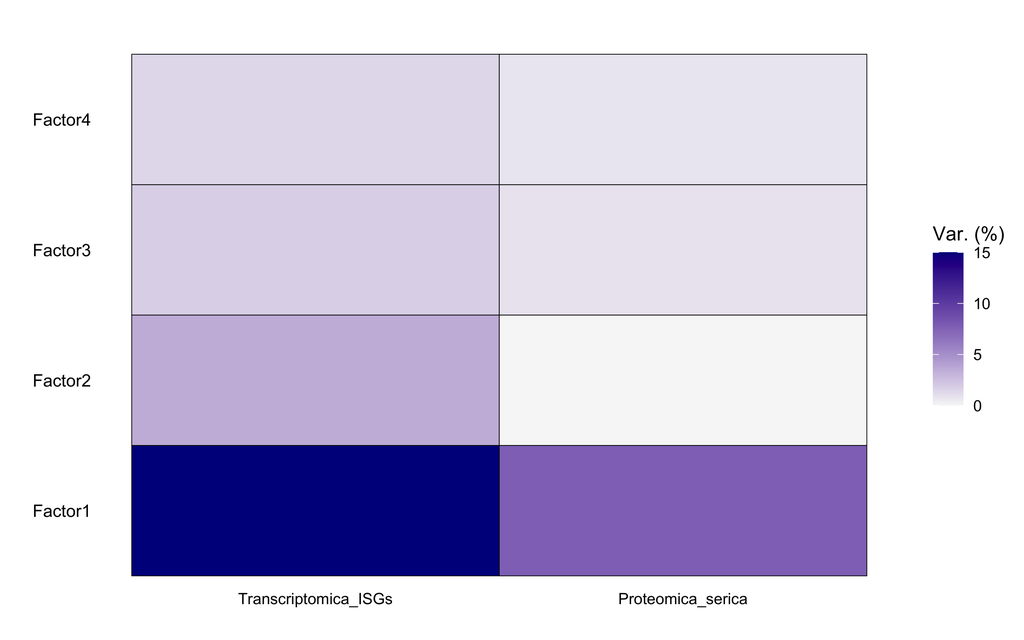

Figura 1. Proporción de varianza explicada por cada factor latente en cada bloque ómico. Los factores se ordenan de mayor a menor varianza explicada global.

```r
plot_variance_explained(MOFAobject_trained, max_r2 = 15)
```

```r
png(paste0(ruta_fig, "Fig1_VarianzaFactor.png"), width = 2800, height = 1800, res = 300)
plot_variance_explained(MOFAobject_trained, max_r2 = 15)
dev.off()
```

## 7.2 Varianza total por bloque

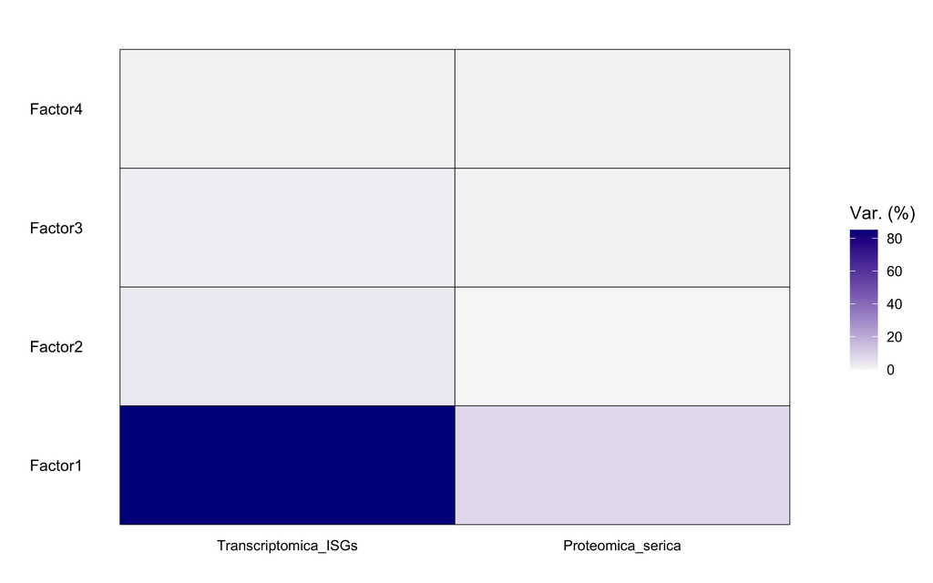

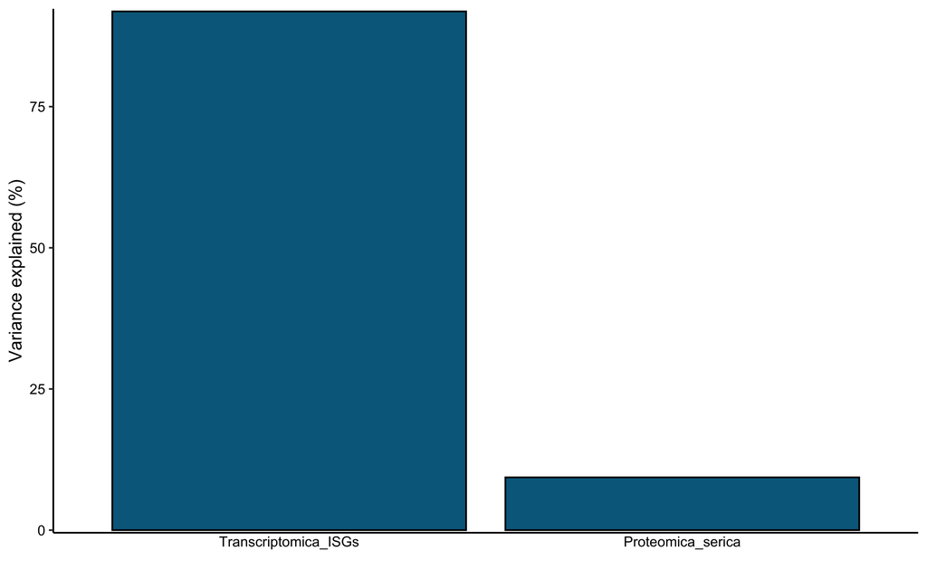

Figura 2. Proporción de varianza total explicada por todos los factores activos en cada bloque ómico.

```r
plot_variance_explained(
  MOFAobject_trained,
  x = "view",
  y = "factor",
  plot_total = TRUE
)
```

```r
png(paste0(ruta_fig, "Fig2_VarianzaTotal.png"), width = 2400, height = 1600, res = 300)
plot_variance_explained(MOFAobject_trained, x = "view", y = "factor", plot_total = TRUE)
```

```r
dev.off()
```

## 7.3 Tabla resumen de varianza

```r
var_exp <- get_variance_explained(MOFAobject_trained)

# Extraer matriz 4 factores × 2 bloques del único grupo
r2_mat <- var_exp$r2_per_factor$group1   # matriz [4 × 2]

tab_var <- as.data.frame(r2_mat) %>%
  tibble::rownames_to_column("Factor") %>%
  pivot_longer(-Factor, names_to = "Bloque", values_to = "R2") %>%
  mutate(
    R2     = round(R2, 3),
    R2_pct = round(R2, 2)
  ) %>%
  arrange(Bloque, desc(R2))

kable(tab_var,
      caption = "Tabla 3. Varianza explicada (R²) por factor y bloque en el modelo MOFA2.",
      col.names = c("Factor", "Bloque", "R²", "R² (%)"),
      align = "llcc") %>%
  kable_styling(bootstrap_options = c("striped", "hover", "condensed"),
                full_width = FALSE, font_size = 13) %>%
  footnote(general = "R² = proporción de varianza explicada por cada factor latente en cada bloque. Valores extraídos de r2_per_factor$group1 (matriz 4 factores × 2 bloques).",
           general_title = "Nota")
```

Tabla 3. Varianza explicada (R²) por factor y bloque en el modelo MOFA2.

| Factor | Bloque | R² | R² (%) |
| --- | --- | --- | --- |
| Factor1 | Proteomica_serica | 7.712 | 7.71 |
| Factor3 | Proteomica_serica | 0.898 | 0.90 |
| Factor4 | Proteomica_serica | 0.735 | 0.74 |
| Factor2 | Proteomica_serica | 0.000 | 0.00 |
| Factor1 | Transcriptomica_ISGs | 85.059 | 85.06 |
| Factor2 | Transcriptomica_ISGs | 3.516 | 3.52 |
| Factor3 | Transcriptomica_ISGs | 1.857 | 1.86 |
| Factor4 | Transcriptomica_ISGs | 1.426 | 1.43 |

Nota  
R² = proporción de varianza explicada por cada factor latente en cada bloque. Valores extraídos de r2_per_factor$group1 (matriz 4 factores × 2 bloques).

```r
r2_mat <- var_exp$r2_per_factor$group1

factores_activos <- which(apply(r2_mat, 1, max) > 1)

cat("→", paste(names(factores_activos), collapse = ", "), "\n")
```

```
## → Factor1, Factor2, Factor3, Factor4
```

```r
cat("Total:", length(factores_activos), "\n")
```

```
## Total: 4
```

## 7.4 Top ISGs por factor

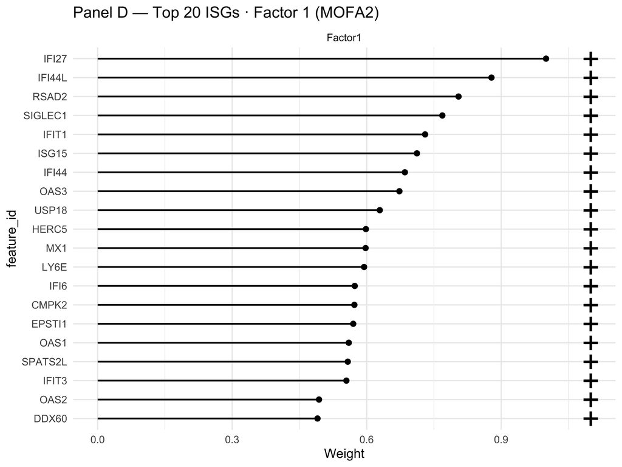

```r
plot_top_weights(
  MOFAobject_trained,
  view      = "Transcriptomica_ISGs",
  factor    = 1,
  nfeatures = 20,
  scale     = TRUE,
  abs       = FALSE
) +
  theme_minimal(base_size = 12) +
  labs(title = "Panel D — Top 20 ISGs · Factor 1 (MOFA2)")
```

```r
png(paste0(ruta_fig, "PanelD_TopISGs_F1.png"), width = 2400, height = 1800, res = 300)
plot_top_weights(MOFAobject_trained, view = "Transcriptomica_ISGs",
                 factor = 1, nfeatures = 20, scale = TRUE)
dev.off()
```

## 7.5 Top proteínas séricas por factor

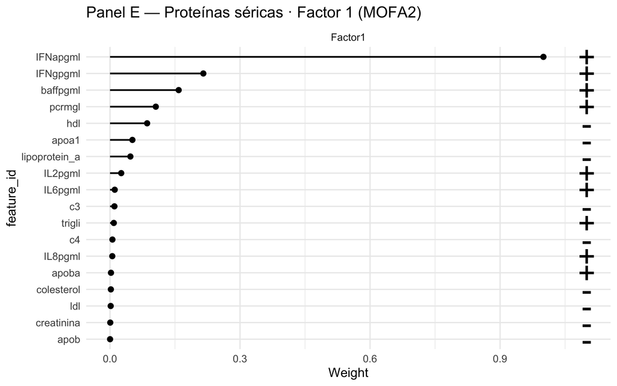

Panel E. Top proteínas séricas con mayor peso (loading) en el Factor 1 del modelo MOFA2.

```r
plot_top_weights(
  MOFAobject_trained,
  view      = "Proteomica_serica",
  factor    = 1,
  nfeatures = length(prot_incluir),
  scale     = TRUE,
  abs       = FALSE
) +
  theme_minimal(base_size = 12) +
  labs(title = "Panel E — Proteínas séricas · Factor 1 (MOFA2)")
```

```r
png(paste0(ruta_fig, "PanelE_TopProt_F1.png"), width = 2400, height = 1600, res = 300)
plot_top_weights(MOFAobject_trained, view = "Proteomica_serica",
                 factor = 1, nfeatures = length(prot_incluir), scale = TRUE)
dev.off()
```

## 7.6 Tabla de loadings — Factor 1

```r
# ── Función de extracción de loadings ────────────────────────────────────────
extraer_loadings_mofa <- function(modelo, vista, factor_num, n_top = 20) {
  get_weights(modelo,
              views         = vista,
              factors       = factor_num,
              abs           = FALSE,
              as.data.frame = TRUE) %>%
    mutate(feature = as.character(feature)) %>%
    filter(value != 0) %>%
    mutate(abs_loading = abs(value)) %>%
    arrange(desc(abs_loading)) %>%
    slice_head(n = n_top) %>%
    mutate(
      value       = round(value,       4),
      abs_loading = round(abs_loading, 4),
      direccion   = ifelse(value > 0, "↑ Positivo", "↓ Negativo")
    ) %>%
    select(feature, value, abs_loading, direccion)
}

# ── Etiquetas proteínas séricas ───────────────────────────────────────────────
etiq_prot <- c(
  IFNapgml = "IFN-α", IFNgpgml = "IFN-γ", IL2pgml = "IL-2",
  IL6pgml = "IL-6", IL8pgml = "IL-8", baffpgml = "BAFF",
  c3 = "C3", c4 = "C4", pcrmgl = "PCR (mg/L)",
  creatinina = "Creatinina (mg/dL)", colesterol = "Colesterol total (mg/dL)",
  trigli = "Triglicéridos (mg/dL)", hdl = "HDL (mg/dL)", ldl = "LDL (mg/dL)",
  apoa1 = "Apo A-I (mg/dL)", apob = "Apo B (mg/dL)", apoba = "Cociente Apo B/A-I",
  lipoprotein_a = "Lipoproteína(a) (mg/dL)", got = "GOT/AST (U/L)",
  gpt = "GPT/ALT (U/L)", ggt = "GGT (U/L)", prot_tot = "Proteínas totales (g/dL)"
)

etiquetar_prot <- function(df) {
  df %>% mutate(feature = dplyr::recode(feature, !!!etiq_prot, .default = feature))
}

# ── Tabla 4A: Top 20 ISGs — Factor 1 ─────────────────────────────────────────
tab_isg_f1 <- extraer_loadings_mofa(MOFAobject_trained,
                                     "Transcriptomica_ISGs", 1, n_top = 20)

kable(tab_isg_f1,
      caption   = "Tabla 4A. Top 20 ISGs con mayor peso en el Factor 1 (bloque transcriptómico).",
      col.names = c("Gen ISG", "Loading", "Abs. Loading", "Dirección"),
      align     = "lccc") %>%
  kable_styling(bootstrap_options = c("striped", "hover", "condensed"),
                full_width = FALSE, font_size = 13) %>%
  footnote(general = "Loadings positivos: mayor expresión asociada al polo positivo del Factor 1. Loadings negativos: asociación inversa.",
           general_title = "Nota")
```

Tabla 4A. Top 20 ISGs con mayor peso en el Factor 1 (bloque transcriptómico).

| Gen ISG | Loading | Abs. Loading | Dirección |
| --- | --- | --- | --- |
| IFI27 | 2.4402 | 2.4402 | ↑ Positivo |
| IFI44L | 2.1432 | 2.1432 | ↑ Positivo |
| RSAD2 | 1.9640 | 1.9640 | ↑ Positivo |
| SIGLEC1 | 1.8758 | 1.8758 | ↑ Positivo |
| IFIT1 | 1.7820 | 1.7820 | ↑ Positivo |
| ISG15 | 1.7376 | 1.7376 | ↑ Positivo |
| IFI44 | 1.6719 | 1.6719 | ↑ Positivo |
| OAS3 | 1.6421 | 1.6421 | ↑ Positivo |
| USP18 | 1.5353 | 1.5353 | ↑ Positivo |
| HERC5 | 1.4598 | 1.4598 | ↑ Positivo |
| MX1 | 1.4581 | 1.4581 | ↑ Positivo |
| LY6E | 1.4500 | 1.4500 | ↑ Positivo |
| IFI6 | 1.3990 | 1.3990 | ↑ Positivo |
| CMPK2 | 1.3971 | 1.3971 | ↑ Positivo |
| EPSTI1 | 1.3909 | 1.3909 | ↑ Positivo |
| OAS1 | 1.3666 | 1.3666 | ↑ Positivo |
| SPATS2L | 1.3612 | 1.3612 | ↑ Positivo |
| IFIT3 | 1.3536 | 1.3536 | ↑ Positivo |
| OAS2 | 1.2047 | 1.2047 | ↑ Positivo |
| DDX60 | 1.1964 | 1.1964 | ↑ Positivo |

Nota  
Loadings positivos: mayor expresión asociada al polo positivo del Factor 1. Loadings negativos: asociación inversa.

```r
# ── Tabla 4B: Proteínas séricas — Factor 1 ───────────────────────────────────
tab_prot_f1 <- extraer_loadings_mofa(MOFAobject_trained,
                                      "Proteomica_serica", 1,
                                      n_top = length(prot_incluir)) %>%
  etiquetar_prot()

kable(tab_prot_f1,
      caption   = "Tabla 4B. Proteínas séricas con mayor peso en el Factor 1 (bloque proteómico).",
      col.names = c("Proteína sérica", "Loading", "Abs. Loading", "Dirección"),
      align     = "lccc") %>%
  kable_styling(bootstrap_options = c("striped", "hover", "condensed"),
                full_width = FALSE, font_size = 13) %>%
  footnote(general = "Ordenadas por Abs. Loading descendente. Solo se muestran variables con loading ≠ 0.",
           general_title = "Nota")
```

Tabla 4B. Proteínas séricas con mayor peso en el Factor 1 (bloque proteómico).

| Proteína sérica | Loading | Abs. Loading | Dirección |
| --- | --- | --- | --- |
| IFN-α | 0.7493 | 0.7493 | ↑ Positivo |
| IFN-γ | 0.1614 | 0.1614 | ↑ Positivo |
| BAFF | 0.1187 | 0.1187 | ↑ Positivo |
| PCR (mg/L) | 0.0792 | 0.0792 | ↑ Positivo |
| HDL (mg/dL) | -0.0642 | 0.0642 | ↓ Negativo |
| Apo A-I (mg/dL) | -0.0387 | 0.0387 | ↓ Negativo |
| Lipoproteína(a) (mg/dL) | -0.0352 | 0.0352 | ↓ Negativo |
| IL-2 | 0.0194 | 0.0194 | ↑ Positivo |
| IL-6 | 0.0082 | 0.0082 | ↑ Positivo |
| C3 | -0.0076 | 0.0076 | ↓ Negativo |
| Triglicéridos (mg/dL) | 0.0065 | 0.0065 | ↑ Positivo |
| C4 | -0.0042 | 0.0042 | ↓ Negativo |
| IL-8 | 0.0040 | 0.0040 | ↑ Positivo |
| Cociente Apo B/A-I | 0.0017 | 0.0017 | ↑ Positivo |
| Colesterol total (mg/dL) | -0.0015 | 0.0015 | ↓ Negativo |
| LDL (mg/dL) | -0.0012 | 0.0012 | ↓ Negativo |
| Creatinina (mg/dL) | -0.0005 | 0.0005 | ↓ Negativo |
| Apo B (mg/dL) | -0.0001 | 0.0001 | ↓ Negativo |

Nota  
Ordenadas por Abs. Loading descendente. Solo se muestran variables con loading ≠ 0.

# 8 Bloque 5. Análisis de factores latentes

## 8.1 Extracción de scores

```r
factor_scores <- get_factors(MOFAobject_trained)$group1
stopifnot(is.matrix(factor_scores))
cat("✓ Dimensiones:", dim(factor_scores), "\n")
```

```
## ✓ Dimensiones: 251 4
```

```r
cat("✓ Factores:", colnames(factor_scores), "\n")
```

```
## ✓ Factores: Factor1 Factor2 Factor3 Factor4
```

```r
# Base alineada para todos los chunks del bloque 5
muestras_comunes <- intersect(rownames(factor_scores), df_mofa$id2)
fs_alin <- factor_scores[muestras_comunes, ]
df_alin <- df_mofa %>%
  filter(id2 %in% muestras_comunes) %>%
  arrange(match(id2, muestras_comunes))

cat("✓ Muestras alineadas:", length(muestras_comunes), "\n")
```

```
## ✓ Muestras alineadas: 251
```

## 8.2 Panel A — Scores MOFA2 por estado de remisión DORIS

El estado de remisión DORIS es una variable **completamente externa** al modelo MOFA2: no formó parte de ninguno de los dos bloques de entrada (transcriptómico ni proteómico). Su uso como variable de anotación permite una validación clínica independiente de los factores latentes.

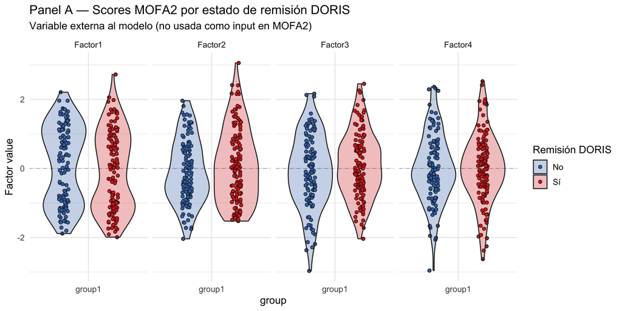

Panel A. Distribución de los scores de los factores latentes MOFA2 según el estado de remisión DORIS (variable externa al modelo). Los violines representan la densidad de distribución; los puntos muestran observaciones individuales.

```r
col_doris <- c("No" = "#4575b4", "Sí" = "#d73027")

p_doris <- plot_factor(
  MOFAobject_trained,
  factors      = factores_activos,
  color_by     = "doris",
  dot_size     = 1.5,
  dodge        = TRUE,
  legend       = TRUE,
  add_violin   = TRUE,
  violin_alpha = 0.3
) +
  scale_color_manual(values = col_doris, name = "Remisión DORIS") +
  scale_fill_manual(values  = col_doris, name = "Remisión DORIS") +
  theme_minimal(base_size = 12) +
  labs(
    title    = "Panel A — Scores MOFA2 por estado de remisión DORIS",
    subtitle = "Variable externa al modelo (no usada como input en MOFA2)"
  )

print(p_doris)
```

```r
ggsave(paste0(ruta_fig, "PanelA_FactoresDORIS.png"),
       plot = p_doris, width = 10, height = 5, dpi = 300, bg = "white")
```

## 8.3 Panel B — Scores MOFA2 por estado LLDAS

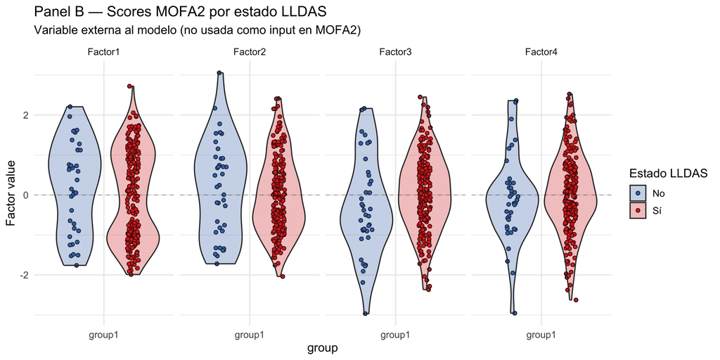

Panel B. Distribución de los scores de los factores latentes MOFA2 según el estado LLDAS (variable externa al modelo).

```r
col_lldas <- c("No" = "#4575b4", "Sí" = "#d73027")

p_lldas <- plot_factor(
  MOFAobject_trained,
  factors      = factores_activos,
  color_by     = "lldas",
  dot_size     = 1.5,
  dodge        = TRUE,
  legend       = TRUE,
  add_violin   = TRUE,
  violin_alpha = 0.3
) +
  scale_color_manual(values = col_lldas, name = "Estado LLDAS") +
  scale_fill_manual(values  = col_lldas, name = "Estado LLDAS") +
  theme_minimal(base_size = 12) +
  labs(
    title    = "Panel B — Scores MOFA2 por estado LLDAS",
    subtitle = "Variable externa al modelo (no usada como input en MOFA2)"
  )

print(p_lldas)
```

```r
ggsave(paste0(ruta_fig, "PanelB_FactoresLLDAS.png"),
       plot = p_lldas, width = 10, height = 5, dpi = 300, bg = "white")
```

[figure not shown]

```r
p_sledai <- plot_factor(
  MOFAobject_trained,
  factors  = factores_activos,
  color_by = "sledai_cat",
  dot_size = 1.5
) +
  scale_color_distiller(palette = "YlOrRd", direction = 1,
                        name = "SLEDAI-2K") +
  theme_minimal(base_size = 12) +
  labs(
    title    = "Panel C — Scores MOFA2 coloreados por SLEDAI-2K",
    subtitle = "Variable externa al modelo"
  )

print(p_sledai)
```

```r
ggsave(paste0(ruta_fig, "PanelC_FactoresSLEDAI.png"),
       plot = p_sledai, width = 10, height = 5, dpi = 300, bg = "white")
```

[figure not shown]

```r
p_sledas <- plot_factor(
  MOFAobject_trained,
  factors  = factores_activos,
  color_by = "sledas_cat",
  dot_size = 1.5
) +
  scale_color_distiller(palette = "YlOrRd", direction = 1,
                        name = "SLE-DAS") +
  theme_minimal(base_size = 12) +
  labs(
    title    = "Panel D — Scores MOFA2 coloreados por SLE-DAS",
    subtitle = "Variable externa al modelo"
  )

print(p_sledas)
```

```r
ggsave(paste0(ruta_fig, "PanelD_FactoresSLEDAS.png"),
       plot = p_sledas, width = 10, height = 5, dpi = 300, bg = "white")
```

## 8.6 Tabla de correlaciones Spearman — Factores × Covariables clínicas

```r
clin_cont <- list(
  list(var = "sledai", etiq = "SLEDAI-2K"),
  list(var = "sledas", etiq = "SLE-DAS"),
  list(var = "slicc",  etiq = "SLICC-SDI")
)

corr_tabla <- purrr::map_dfr(clin_cont, function(cv) {
  y <- df_alin[[cv$var]]
  purrr::map_dfr(colnames(fs_alin), function(fac) {
    x   <- fs_alin[, fac]
    idx <- complete.cases(x, y)
    ct  <- cor.test(x[idx], y[idx], method = "spearman",
                    exact = FALSE)
    tibble(
      Covariable = cv$etiq,
      Factor     = fac,
      rho        = round(ct$estimate, 3),
      p_valor    = round(ct$p.value,  4)
    )
  })
}) %>%
  mutate(
    p_adj = round(p.adjust(p_valor, method = "BH"), 4),
    Sig   = case_when(
      p_adj < 0.001 ~ "***",
      p_adj < 0.01  ~ "**",
      p_adj < 0.05  ~ "*",
      TRUE          ~ "ns"
    )
  )

kable(corr_tabla,
      caption   = "Tabla 5. Correlaciones de Spearman entre los factores latentes MOFA2 y las covariables clínicas continuas (corrección FDR de Benjamini-Hochberg).",
      col.names = c("Covariable", "Factor", "ρ Spearman", "p", "p adj (BH)", "Sig."),
      align     = "llcccc") %>%
  kable_styling(bootstrap_options = c("striped", "hover", "condensed"),
                full_width = FALSE, font_size = 13) %>%
  footnote(
    general = "ρ: coeficiente de Spearman. p adj: p-valor ajustado por FDR (Benjamini-Hochberg). *** p < 0,001; ** p < 0,01; * p < 0,05; ns: no significativo. Todas las covariables son externas al modelo MOFA2.",
    general_title = "Nota"
  )
```

Tabla 5. Correlaciones de Spearman entre los factores latentes MOFA2 y las covariables clínicas continuas (corrección FDR de Benjamini-Hochberg).

Covariable

Factor

ρ Spearman

p

p adj (BH)

Sig.

SLEDAI-2K

Factor1

0.187

0.0029

0.0174

SLEDAI-2K

Factor2

0.045

0.4732

0.8946

ns

SLEDAI-2K

Factor3

-0.009

0.8875

0.8946

ns

SLEDAI-2K

Factor4

-0.021

0.7413

0.8946

ns

SLE-DAS

Factor1

0.198

0.0017

0.0174

SLE-DAS

Factor2

0.022

0.7307

0.8946

ns

SLE-DAS

Factor3

-0.025

0.6970

0.8946

ns

SLE-DAS

Factor4

0.016

0.8000

0.8946

ns

SLICC-SDI

Factor1

0.140

0.0269

0.1076

ns

SLICC-SDI

Factor2

0.122

0.0538

0.1614

ns

SLICC-SDI

Factor3

0.024

0.7089

0.8946

ns

SLICC-SDI

Factor4

0.008

0.8946

0.8946

ns

Nota

ρ: coeficiente de Spearman. p adj: p-valor ajustado por FDR (Benjamini-Hochberg). *** p < 0,001; ** p < 0,01; * p < 0,05; ns: no significativo. Todas las covariables son externas al modelo MOFA2.

## 8.7 Tabla de Wilcoxon — Factores × Variables binarias de remisión

```r
scores_clin <- tibble(
  id2 = rownames(fs_alin),
  F1  = fs_alin[, "Factor1"],
  F2  = fs_alin[, "Factor2"],
  F3  = fs_alin[, "Factor3"],
  F4  = fs_alin[, "Factor4"]
) %>%
  left_join(df_mofa %>% select(id2, lldas, doris), by = "id2") %>%
  mutate(
    lldas_num = as.integer(lldas) - 1L,   # "No"→0, "Sí"→1
    doris_num = as.integer(doris) - 1L
  )

resultados_wilcox <- purrr::map_dfr(c("F1", "F2", "F3", "F4"), function(fac) {
  purrr::map_dfr(list(
    list(var = "lldas_num", etiq = "LLDAS"),
    list(var = "doris_num", etiq = "DORIS")
  ), function(v) {
    datos <- scores_clin %>% filter(!is.na(.data[[v$var]]))
    g0 <- datos[[fac]][datos[[v$var]] == 0]
    g1 <- datos[[fac]][datos[[v$var]] == 1]
    wt <- wilcox.test(g0, g1)
    tibble(
      Factor   = fac,
      Variable = v$etiq,
      n_No     = length(g0),
      n_Si     = length(g1),
      W        = round(wt$statistic, 1),
      p_valor  = round(wt$p.value, 4)
    )
  })
}) %>%
  mutate(
    p_adj = round(p.adjust(p_valor, method = "BH"), 4),
    Sig   = case_when(
      p_adj < 0.001 ~ "***",
      p_adj < 0.01  ~ "**",
      p_adj < 0.05  ~ "*",
      TRUE          ~ "ns"
    )
  )

kable(resultados_wilcox,
      caption   = "Tabla 6. Test de Wilcoxon-Mann-Whitney entre los scores de los factores latentes MOFA2 y las variables binarias de remisión clínica (LLDAS y DORIS).",
      col.names = c("Factor", "Variable", "n No", "n Sí", "W",
                    "p", "p adj (BH)", "Sig."),
      align     = "llcccccc") %>%
  kable_styling(bootstrap_options = c("striped", "hover", "condensed"),
                full_width = FALSE, font_size = 13) %>%
  footnote(
    general = "Test de Wilcoxon-Mann-Whitney bilateral. n No: no cumple criterios de remisión; n Sí: cumple criterios. p adj: FDR Benjamini-Hochberg. *** p<0,001; ** p<0,01; * p<0,05; ns: no significativo. LLDAS y DORIS son variables externas al modelo MOFA2.",
    general_title = "Nota"
  )
```

Tabla 6. Test de Wilcoxon-Mann-Whitney entre los scores de los factores latentes MOFA2 y las variables binarias de remisión clínica (LLDAS y DORIS).

| Factor | Variable | n No | n Sí | W | p | p adj (BH) | Sig. |
| --- | --- | --- | --- | --- | --- | --- | --- |
| F1 | LLDAS | 38 | 213 | 4531 | 0.2409 | 0.4237 | ns |
| F1 | DORIS | 119 | 132 | 8726 | 0.1292 | 0.4237 | ns |
| F2 | LLDAS | 38 | 213 | 4366 | 0.4398 | 0.5026 | ns |
| F2 | DORIS | 119 | 132 | 7213 | 0.2648 | 0.4237 | ns |
| F3 | LLDAS | 38 | 213 | 3241 | 0.0507 | 0.4056 | ns |
| F3 | DORIS | 119 | 132 | 7076 | 0.1758 | 0.4237 | ns |
| F4 | LLDAS | 38 | 213 | 3692 | 0.3899 | 0.5026 | ns |
| F4 | DORIS | 119 | 132 | 7792 | 0.9147 | 0.9147 | ns |

Nota  
Test de Wilcoxon-Mann-Whitney bilateral. n No: no cumple criterios de remisión; n Sí: cumple criterios. p adj: FDR Benjamini-Hochberg. *** p<0,001; ** p<0,01; * p<0,05; ns: no significativo. LLDAS y DORIS son variables externas al modelo MOFA2.